# Estudio de la Resistencia a Carbapenémicos en Klebsiella pneumoniae: Análisis GWAS para resistencia a meropenem

Author

Affiliation

Jordi Sevilla-Fortuny

Universitat de València (UV)

## Abstract

El incremento global de Klebsiella pneumoniae resistente a carbapenémicos (crKp) representa un desafío crítico para la salud pública debido a la limitada eficacia de los tratamientos disponibles. Este estudio investigó los determinantes genéticos asociados a la resistencia a meropenem, un carbapenémico de amplio uso clínico, mediante un análisis de asociación a nivel del genoma (GWAS) utilizando un conjunto diverso de 1,153 genomas de K. pneumoniae. Los genomas fueron ensamblados y filtrados por calidad, y los análisis incluyeron modelos lineales mixtos para identificar k-meros asociados a concentraciones mínimas inhibitorias (CMI) de meropenem.

El estudio reveló 921,304 k-meros significativamente asociados, destacando genes previamente vinculados a la resistencia como ompK36 y bla_kpc, así como transposasas que podrían facilitar la transferencia horizontal de genes. La población mostró alta diversidad genómica y geográfica, incluyendo 250 secuencias tipo (ST) diferentes, con predominio de los complejos clonales 258 y ST11.

Estos hallazgos resaltan la importancia de la estructura poblacional y los elementos móviles en la resistencia a carbapenémicos. Este enfoque contribuye al entendimiento de los mecanismos genéticos subyacentes a la resistencia, proporcionando bases para estrategias terapéuticas y de vigilancia más efectivas.

## Introducción

En las últimas décadas, el aumento de la resistencia antimicrobiana ha planteado serias amenazas para la salud pública a nivel global. Dentro de este fenómeno, la resistencia a carbapenémicos en *Klebsiella pneumoniae* ha ganado especial atención debido a su papel en infecciones hospitalarias graves y su capacidad para diseminar genes de resistencia a otras bacterias. *Klebsiella pneumoniae* es un patógeno oportunista responsable de una amplia gama de infecciones, incluidas neumonías, infecciones del tracto urinario, bacteriemias y otras infecciones invasivas. Esta bacteria pertenece a la familia *Enterobacteriaceae*, conocida por su habilidad para adquirir y compartir material genético mediante elementos móviles como plásmidos, integrones y transposones.

Los antibióticos carbapenémicos son un tipo de antibióticos ß-lactámicos caracterizados por tener un amplio espectro de acción y constituir la última línea de tratamiento para muchas infecciones bacterianas. Dentro de esta familia podemos encontrar los antibióticos imipenem, ertapenem, doripenem y meropenem. El primer carbapenémico que se utilizó para tratar *K. pneumoniae* fué el imipenem en 1983, y solo dos años más tarde ya se encontraron cepas resistentes. La primera enzima carbapenemasa encontrada en *K. pneumoniae* llamada IMP-1 se descubrió en 1991 aunque fué detectada por primera vez ese mismo año en *Serratia marcescens*<sup>1,2</sup>. A día de hoy, se conocen más genes codificantes de carbapenemasas, como los genes *blaOXA-48* o *blaNDM-1*, siendo los más prevalentes los genes *blaKPC*<sup>3</sup>.

La propagación de *K. pneumoniae* resistente a carbapenémicos no se limita a un entorno local, sino que ha alcanzado proporciones globales, facilitada por la movilidad humana, las transferencias de pacientes entre hospitales y la diseminación en ambientes comunitarios y animales. Ante este escenario, la identificación temprana de mecanismos de resistencia, junto con estrategias efectivas de control de infecciones, se convierte en una prioridad para contener su diseminación y mitigar su impacto clínico y económico.

En este estudio, nos proponemos investigar los elementos genéticos asociados a la resistencia a carbapenémicos, centrándonos específicamente en la resistencia a Meropenem. Para ello, analizaremos un conjunto diverso de genomas de K. pneumoniae generados por Sophia David *et al.*<sup>4</sup> mediante un estudio de asociación a nivel del genoma (GWAS) para evaluar la concentración mínima inhibitoria (CMI) a Meropenem. Este enfoque tiene el potencial de aportar nuevos conocimientos sobre la base genética de la resistencia, lo que podría contribuir a futuras estrategias terapéuticas y de vigilancia.

## Material y métodos

### Descarga de los datos

Los datos del artículo de Sophia David *et al.*<sup>4</sup> están depositados en el ENA bajo el accession PRJEB10018. Se generó el script de descarga de los datos a través de ENA y se ejecutó usando GNU parallel<sup>5</sup> para acelerar la descarga.

### Filtrado de los datos por lecturas

Los datos descargados se subieron al ENA ya sin adaptadores por lo que no ha sido necesario eliminar los adaptadores. Se usó Kraken2 v2.1.3<sup>6</sup> para hacer una asignación taxonómica de las lecturas. Solo se mantuvieron aquellas muestras para las cuales más del 85% de las lecturas estaban asignadas al género *Klebsiella*.

### Ensamblado de genomas y filtrado por ensamblados

Las lecturas descargadas fueron ensambladas usando la herramienta SPAdes v3.15.5<sup>7</sup>. Para seguir las instrucciones del artículo de referencia se ha usado el flag `--cov-cutoff auto` y los valores de *k* para los *k*-meros de 41, 49, 57, 77, 85 y 93. Posteriormente los ensamblados generados se analizaron usando las herramientas kleborate v2.4.0<sup>8,9</sup>, las cuales proporcionan información de los ensamblados tanto a nivel de estadísticas como a nivel de tipado de los ensamblados. Con esta información se filtraron los ensamblados para asegurar la mayor calidad posible de los ensamblados incluidos en el estudio. Se seleccionaron aquellas muestras cuyos ensamblados tenían un número de contigs entre 1 y 800, una asociación taxonómica fuerte a la especie *Klebsiella pneumoniae*, un tamaño total entre 5 y 6 Mb y una asignación de sequence type (ST).

### Análisis GWAS

Para realizar el análisis GWAS usamos la herramienta pyseer v1.3.12<sup>10</sup> para implementar un modelo lineal mixto usando conteos de *k*-meros como predictores y la concentración mínima inhibitoria (CMI) para meropenem como variable dependiente. Los conteos de *k*-meros se generaron con la herramienta fsm-lite (https://github.com/nvalimak/fsm-lite) usando los valores por defecto. Las CMIs se obtuvieron de el material suplementario del artículo de Sophia David *et al*<sup>4</sup>. Debido al formato de las CMIs en el que en muchas ocasiones no se da el valor exacto sino una aproximación (<, >, <=,>=), estos datos se modificaron antes de proporcionarlos al modelo. Si el valor de CMI contenía un signo *=*, entonces se mantenía el valor numérico. Si el valor de CMI estaba acompañado de los un signo *>* o *<* entonces se establecía el valor numérico como el promedio entre el valor actual y la dilución superior o inferior respectivamente.

Debido a que *Klebsiella pneumoniae* es un patógeno con una alta estructura poblacional, se llevó a cabo un análisis evolutivo para determinar esta estructura y corregir los modelos. Se realizó un genoma core al 90% de los aislados de estudio. Para ello primero los genomas se anotaron usando prokka v1.14.6<sup>11</sup>. Luego, con las anotaciones se usó la herramienta panaroo v1.3.4<sup>12</sup> para generar el pangenoma y obtener el genoma core. Usamos la opción más estricta de panaroo para generar los pangenomas `--clean-mode sensitive`. Una vez el alineamiento del genoma core está construido, usamos IQTREE2 v2.2.6<sup>13</sup> para generar una filogenia por máxima verosimilitud usando el modelo evolutivo GTR+F+I+G4. A partir del árbol se generó una matriz de similitudes que nos resume la estructura poblacional. El árbol se visualizó usando iTOL<sup>14</sup>.

Una vez todos los inputs necesarios están generados, se ejecuta el modelo usando pyseer.

### Anotación de los *k*-meros

A partir de los resultados de pyseer se seleccionan los *k*-meros que mostraron asociación significativa con el fenotipo con un nivel de confianza de 0.01. Los p-valores se corrigieron para tests múltiples usando la corrección de bonferroni. Para no ser demasiado estricto, en lugar de usar el número de *k*-meros para la corrección, se usó el número de patrones distintos en los conteos de *k*-meros obtenido con pyseer.

Como *K. pneumoniae* es un patógeno muy diverso, usar un genoma de referencia no es una buena idea, por lo que usamos como genoma de referencia el pangenoma de referencia generado por panaroo. Este pangenoma de referencia se anotó usando prokka. Luego se usaron las funcionalidades de anotación de pyseer para mapear los *k*-meros significativos en el pangenoma de referencia y luego resumir esas anotaciones.

### Visualización de los datos

Las visualizaciones de los datos se han llevado a cabo en R usando la libreria ggplot2 implementada en el paquete tidyverse<sup>15</sup>. Además se han usado las plataformas PathogenWatch y MicroReact para visualizar y dar a conocer los datos de forma interactiva<sup>16,17</sup>.

## Resultados

### Descripción del conjunto de datos

El conjunto de datos original descargado contenía datos de secuenciación para 2.699 secuencias de las cuales 1.668 pasaron el filtro de kraken2. Una vez estas secuencias se ensamblaron, 1.368 pasaron los filtros aplicados a los ensamblados (Figure 1). Finalmente, de estos ensamblados, se acabaron usando 1.153 ensamblados ya que el resto no tenían información de MIC para meropenem. Estos ensamblados, asi como genómica y geográfica de ellos se ha depositado en pathogenwatch y está disponible en el siguiente enlace https://pathogen.watch/collection/fesgrd7va3kc-eib-project.

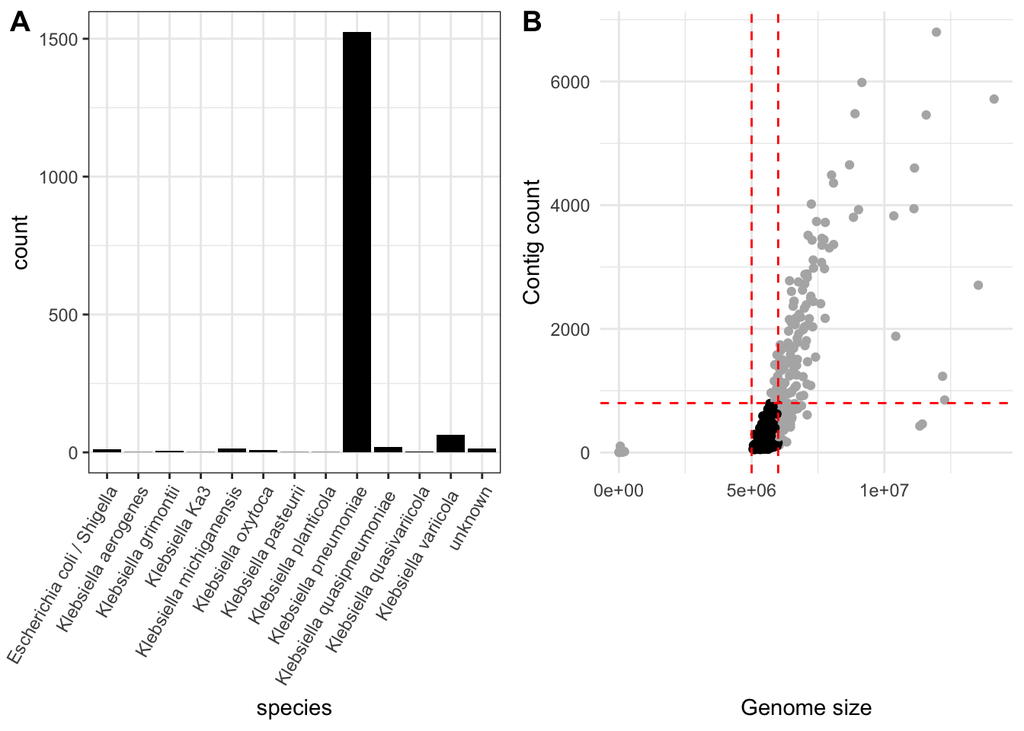

Figure 1: A) Asignación taxonómica de cada ensamblado producida por kleborate. B) Tamaño del genoma en función del número de contigs para los ensamblados analizados. Las líneas rojas indican los límites admitidos para las dos variables. Las muestras que cumplen los parámetros se muestran en negro.

Esta colección resultante es muy diversa, contiene muestras recogidas en 28 países distintos entre el 10/10/2012 y el 4/12/2014. Los paises que más aportan son Italia (20,7%, n = 239), Turquía (9,3%, n = 108) y España (8,1%, n = 94) (Figure 2 A). Además se han encontrado 250 STs distintos en la colección. Los más abundantes son el ST512 (12,8%, n = 148), ST11 (10,5%, n = 122) y ST15 (5,2%, n = 61) (Figure 2 B).

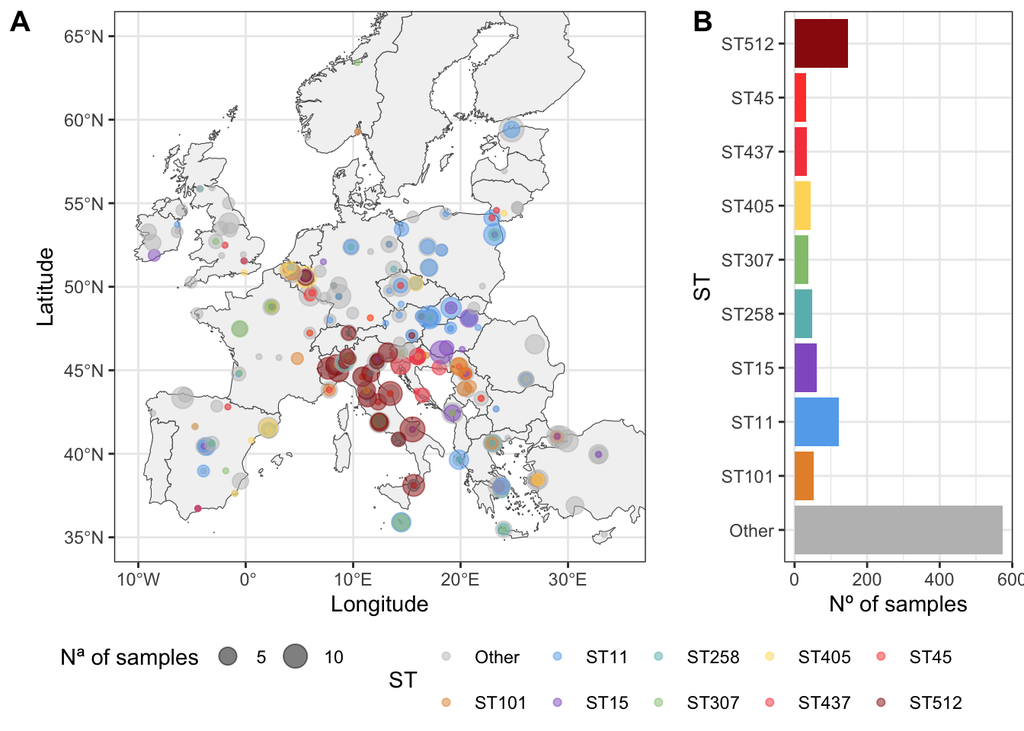

Figure 2: A) Distribución geográfica de las muestras del estudio. Las muestras se colorean por ST. El tamaño de los puntos indica el número de muestras. B) Conteo de número de muestras por ST. Solo se muestran los STs con más de 30 muestras, el resto se agrupan como “other”.

### Análisis de la estructura poblacional

Panaroo reveló que 4.330 genes son compartidos al menos por el 90% de las secuencias. Además se han encontrado 25.266 genes accesorios, es decir, compartidos por entre el 0 y el 15% de las secuencias. Cuando se combinaron los alineamientos individuales de los genes del core, se obtuvo un alineamiento final con 3.716.105 pares de bases de las cuales 20.5865 eran variables. Podemos ver que una amplia parte de los aislados corresponden al complejo clonal 258, que corresponde al clado que incluye al ST258, ST512 y ST437. Además se puede ver como este clado acumula gran parte de los aislados resistentes. También se vé una acumulación grande de aislados del ST11 (Figure 3). Los datos se pueden visualizar de forma interactiva en microract https://microreact.org/project/eib-project.

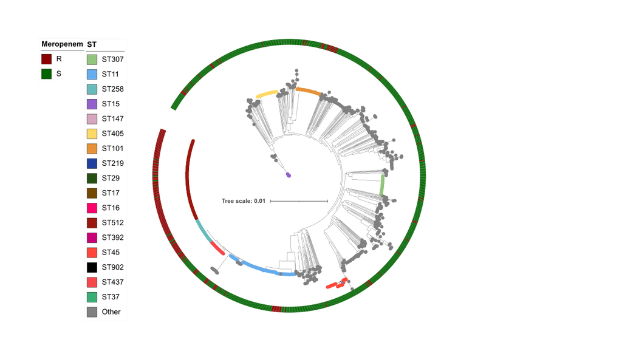

Figure 3: Árbol máximo-verosimil de las 1.153 muestras estudiadas usando un alineamiento core con 3.716.105 posiciones y un modelo evolutivo GTR+G4+I+F. Las hojas del árbol están coloreadas por ST y se muestra en el aro la resustencia (R) o susceptibildad (S) a meropenem.

### *ompK36* como principal gen asociado a resistencia a meropenem

El conteo de *k*-meros sobre los ensamblados reveló 15.795.818 patrones distintos sobre 101.096.369 *k*-meros distintos. Una vez analizado el modelo lineal mixto, se encontraron 921.304 *k*-meros con una asociación significativa con la CMI de meropenem. Además, el modelo reveló una heredabilidad del fenotipo de 0.61, indicando que una grán parte de la varianza del fenotipo puede no estar determinada por los genes. Cuando anotamos los *k*-meros significativos encontramos diversos genes asociados. Entre las 10 anotaciones que han obtenido un mayor p-valor para la asociación, encontramos 3 transposasas (COGIHDDD_16565, COGIHDDD_19241 y COGIHDDD_08666) indicando una posible gran importancia de la transferencia génica horizontal en el fenotipo. Una de las anotaciones determinadas que más significación ha obtenido es el gen *ompC*, que en *K. pneumoniae* corresponde a el gen *ompK36*. Además también encontramos un gen de resistencia a betalactamasas (*bla*). Cuando analizamos en detalle este hit, corresponde al gen *bla_kpc* que es un conocido gen de resistencia a carbapenémicos. Fuera de este top 10 encontramos otros genes de resistencia a carbapenémicos como el gen que codifica para la enzima NDM (Table 1; Figure 4). En la Figure 4 se puede ver como tenemos una conjunto de genes grande con un p-valor similar, formando una línea cai horizontal en el gráfico, esto está indicando que posiblemente la estructura poblacional está influyendo en el resultado pese a haber corregido por ésta en el modelo.

Table 1: Resumen de las 10 anotaciones con una mayor asociación con la CMI a meropenem.

| Gene | nº k-mers | -log20(p-value) máximo | maf promedio | efecto promedio |
| --- | --- | --- | --- | --- |
| COGIHDDD_16565 | 6218 | 78.68825 | 0.2190848 | 20.80135 |
| COGIHDDD_08753 | 1244 | 78.68825 | 0.2227862 | 20.63586 |
| ompC_2 | 305 | 73.93181 | 0.4885548 | 18.93672 |
| COGIHDDD_19241 | 2844 | 66.46092 | 0.2198579 | 20.29527 |
| xerC_3 | 3478 | 64.16241 | 0.2178813 | 21.37201 |
| groL_4 | 441 | 61.85699 | 0.0645524 | 20.39735 |
| COGIHDDD_06856 | 841 | 60.25026 | 0.0548950 | 16.52039 |
| COGIHDDD_08666 | 902 | 58.42251 | 0.2225721 | 20.27226 |
| COGIHDDD_01743 | 2193 | 57.70774 | 0.2229394 | 21.31653 |
| bla_2 | 1916 | 57.58503 | 0.2172505 | 18.80990 |

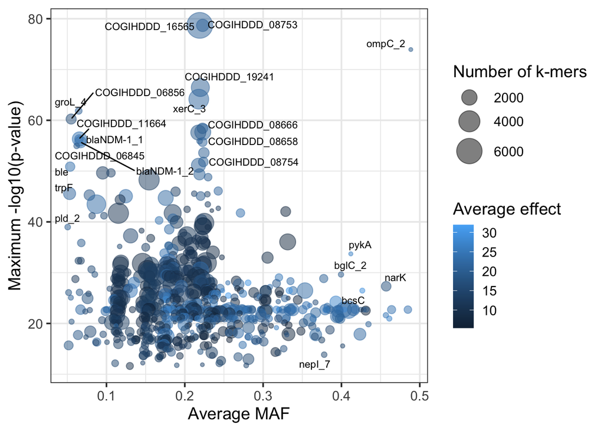

Figure 4: P-valor máximo en función de la MAF promedio para las anotaciones obtenidas. El tamaño de los puntos indica el número de k-meros que han sido anotados. El color de los puntos hace referencia al efecto promedio sobre el modelo de los k-meros anotados.

## Conclusiones

K. pneumoniae es un patógeno bacteriano oportunista causante de una gran cantidad de muertes anuales<sup>18</sup>. Además su capacidad para adquirir resistencias a los antibióticos que se usan para tratarla hace que las infecciones se compliquen por falta de tratamiento y obliguen a buscar nuevas opciones. En concreto, la acumulación de resistencias a carbapenémicos supone una de las mayores preocupaciones en Europa en los últimos años. En este estudio hemos analizado un dataset diverso de 1.153 aislados recogidos en toda Europa bajo el marco del estudio realizado en el artículo de Sophia David *et al*<sup>4</sup>.

Analizando los datos hemos visto que la población de *K. pneumoniae* en Europa es extremadamente diversa, al menos en términos de STs. Esto es concordante con la epidemiología de este patógeno que está asociado a brotes nosocomiales más que a grandes expansiones clonales. Sin embargo este último fenómeno también se ha dado con el ST258<sup>4</sup>. Este ST, acompañado de su descendiente el ST512 provocaron grandes brotes de *K. pneumoniae* carbapenem resistente en Estados Unidos, y más tarde llegó a Europa. Estos clones se encuentran también en gran medida en nuestros datos, confirmando esa expansión a Europa. Además, la resistencia a carbapenems en estos grupos está mayormente asociada a la presencia de una carbapenemasa de la familia KPC<sup>19</sup> tal como vemos en nuestros datos (Table 1).

Además, según nuestros datos, otro gen que tiene un gran efecto sobre el fenotipo resistente a meropenem es el gen *ompK36*<sup>20</sup> (*ompC* en *E. coli*) (Table 1). Este gen codifica para una porina que regula, entre otros, la entrada de las moléculas de antibiótico en el interior de la célula. Por este motivo, mutaciones en este gen están reconocidas como mutaciones que producen resistencia a carbapenems. Además encontramos otros muchos genes de los cuales no se tiene información funcional, pero que muestran una fuerte asociación con el fenotipo, abriendo la puerta al estudio de todos estos genes.

Sin embargo, este estudio tiene algunas limitaciones. El modelo lineal mixto generado muestra una heredabilidad del 0.61 lo cual indica que el genotipo no explica demasiado bien el fenotipo, indicando que igual otro enfoque podría ser necesario. Esto se refuerza con los resultados de las anotaciones de los *k*-meros significativos, que muestran un efecto de la estructura poblacional pese a haberla corregido (Figure 4).

En resumen, este estudio muestra la diversidad de la población de *K. pneumoniae* en Europa y muestra como un análisis de GWAS puede ser de utilidad para desenmascarar los determinantes genéticos de la resistencia a antimicrobianos. Este mismo enfoque puede usarse para descifrar la resistencia a otros antibióticos.

## Disponibilidad de los datos

Los datos generados en este estudio así como los scripts para el análisis de los datos están disponibles en GitHub en el siguiente enlace: https://github.com/SeviJordi/EIB_project. Además los ensamblados estudiados, junto a los metadatos asociados están disponibles para explorar y descargar en PathogenWatch (https://pathogen.watch/collection/fesgrd7va3kc-eib-project)

## Agradecimientos

La computación se llevó a cabo en el HPC cluster Garnatxa en el Instituto de Biología Integrativa de Sistemas (I2SysBio). I2SysBio es un centro de investigación mixto formado por la Universidad de Valencia (UV) y el Consejo Superior de Investigaciones Científicas (CSIC).

## Referencias

1.

Haruta, S. *et al.* [Functional analysis of the active site of a metallo-beta-lactamase proliferating in japan](https://doi.org/10.1128/AAC.44.9.2304-2309.2000). *Antimicrobial Agents and Chemotherapy* **44**, 2304–2309 (2000).

2.

Osano, E. *et al.* [Molecular characterization of an enterobacterial metallo beta-lactamase found in a clinical isolate of serratia marcescens that shows imipenem resistance](https://doi.org/10.1128/AAC.38.1.71). *Antimicrobial Agents and Chemotherapy* **38**, 71–78 (1994).

3.

Munoz-Price, L. S. *et al.* Clinical epidemiology of the global expansion of klebsiella pneumoniae carbapenemases. *The Lancet.Infectious diseases* **13**, 785–796 (2013).

4.

David, S. *et al.* [Epidemic of carbapenem-resistant klebsiella pneumoniae in europe is driven by nosocomial spread](https://doi.org/10.1038/s41564-019-0492-8). *Nature microbiology* **4**, 1919–1929 (2019).

5.

Tange, O. *GNU Parallel 2018*. (Ole Tange, 2018). doi:10.5281/zenodo.1146014.

6.

Wood, D. E., Lu, J. & Langmead, B. [Improved metagenomic analysis with kraken 2](https://doi.org/10.1186/s13059-019-1891-0). *Genome biology* **20**, 257–0 (2019).

7.

Prjibelski, A., Antipov, D., Meleshko, D., Lapidus, A. & Korobeynikov, A. [Using SPAdes de novo assembler](https://doi.org/10.1002/cpbi.102). *Current protocols in bioinformatics* **70**, e102 (2020).

8.

Lam, M. M. C. *et al.* [A genomic surveillance framework and genotyping tool for klebsiella pneumoniae and its related species complex](https://doi.org/10.1038/s41467-021-24448-3). *Nature communications* **12**, 4188–3 (2021).

9.

Wyres, K. L. *et al.* [Identification of klebsiella capsule synthesis loci from whole genome data](https://doi.org/10.1099/mgen.0.000102). *Microbial genomics* **2**, e000102 (2016).

10.

Lees, J. A., Galardini, M., Bentley, S. D., Weiser, J. N. & Corander, J. [Pyseer: A comprehensive tool for microbial pangenome-wide association studies](https://doi.org/10.1093/bioinformatics/bty539). *Bioinformatics (Oxford, England)* **34**, 4310–4312 (2018).

11.

Seemann, T. [Prokka: Rapid prokaryotic genome annotation](https://doi.org/10.1093/bioinformatics/btu153). *Bioinformatics (Oxford, England)* **30**, 2068–2069 (2014).

12.

Tonkin-Hill, G. *et al.* [Producing polished prokaryotic pangenomes with the panaroo pipeline](https://doi.org/10.1186/s13059-020-02090-4). *Genome biology* **21**, 180–4 (2020).

13.

Minh, B. Q. *et al.* [IQ-TREE 2: New models and efficient methods for phylogenetic inference in the genomic era](https://doi.org/10.1093/molbev/msaa015). *Molecular biology and evolution* **37**, 1530–1534 (2020).

14.

Letunic, I. & Bork, P. [Interactive tree of life (iTOL) v6: Recent updates to the phylogenetic tree display and annotation tool](https://doi.org/10.1093/nar/gkae268). *Nucleic acids research* **52**, W78–W82 (2024).

15.

Wickham, H. *et al.* [Welcome to the tidyverse](https://doi.org/10.21105/joss.01686). *Journal of Open Source Software* **4**, 1686 (2019).

16.

Argimon, S. *et al.* [Microreact: Visualizing and sharing data for genomic epidemiology and phylogeography](https://doi.org/10.1099/mgen.0.000093). *Microbial genomics* **2**, e000093 (2016).

17.

Argimon, S. *et al.* [Rapid genomic characterization and global surveillance of klebsiella using pathogenwatch](https://doi.org/10.1093/cid/ciab784). *Clinical infectious diseases : an official publication of the Infectious Diseases Society of America* **73**, S325–S335 (2021).

18.

Cassini, A. *et al.* Attributable deaths and disability-adjusted life-years caused by infections with antibiotic-resistant bacteria in the EU and the european economic area in 2015: A population-level modelling analysis. *The Lancet.Infectious diseases* **19**, 56–66 (2019).

19.

Arnold, R. S. *et al.* [Emergence of klebsiella pneumoniae carbapenemase-producing bacteria](https://doi.org/10.1097/SMJ.0b013e3181fd7d5a). *Southern medical journal* **104**, 40–45 (2011).

20.

Wong, J. L. C. *et al.* [OmpK36-mediated carbapenem resistance attenuates ST258 klebsiella pneumoniae in vivo](https://doi.org/10.1038/s41467-019-11756-y). *Nature communications* **10**, 3957–y (2019).